# Using the TM package for Word Clouds

Sandra Pérez

08 October 2021

# Introduction: The Power of Visuals

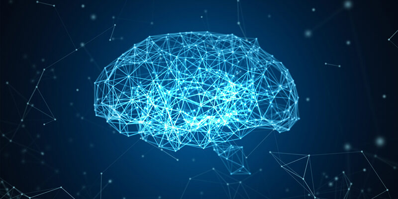

## Learning Objectives

Specifically, with this code-through tutorial, we will learn how to visualizing and communicating statistical models with effect plots using R Markdown to blend exposition, R code and R output into nice reports and presentations creating easy-to-read graphics.

## Our Data

This table show some of the content of the dataset we are using. We are going to use the 2019 ASU salaries database.

```r
URL <- 'https://docs.google.com/spreadsheets/d/1RoiO9bfpbXowprWdZrgtYXG9_WuK3NFemwlvDGdym7E/export?gid=1948400967&format=csv'
datos <- read.csv( URL )
head (datos[c(1,2,3,4)],10) %>% knitr::kable()
```

| Calendar.Year | Full.Name | Job.Description | Department.Description |
| --- | --- | --- | --- |
| 2019 | Abadjivor,Enyah | Coordinator | Research Division 2 Tempe |
| 2019 | Abbas,James | Assoc Professor | Sch Biological & Hlth Sys Engr |
| 2019 | Abbaszadegan,Morteza | Professor | Sch Sustain Engr & Built Envrn |
| 2019 | Abbe,Scott | Tech Support Analyst Coord | Engineering Technical Services |
| 2019 | Abbl,Norma | Sr HR Consultant | HR Partners |
| 2019 | Abbott,David | Assoc Professor | Shesc |
| 2019 | Abbott,Joshua | Assoc Professor | School of Sustainability |
| 2019 | Abbott,Joshua | Dir College of Law | College Of Law |
| 2019 | Abdalla,Mohamed | Senior Program Manager | ASU Wrigley Institute |
| 2019 | Abdollahi,Amir | Web Application Developer (IT) | DEV Architect |

## Libray of Packages

We will be needing the following libraries:

```r
# library ( dplyr )  # helps organize our data
# library ( tm )  # data mining
# library ( wordcloud )  # creates the wordclouds
# library ( wordcloud2 )  # creates the wordclouds
# library ( RColorBrewer ) #  palette colors for cloud
```

# TM: Text Mining

## TM Package

The tm package, created by Ingo Feinerer, offers a powerful text data mining language for depurate complex text information to a nice clean ready-to-use data. ggplot2 is a plotting package that makes it simple to create complex plots from data in a data frame. It provides a more programmatic interface for specifying what variables to plot, how they are displayed, and general visual properties.

## Installing the Package

For the tm library, you can type in the R console: install.packages(“tm”) or you can follow these steps:

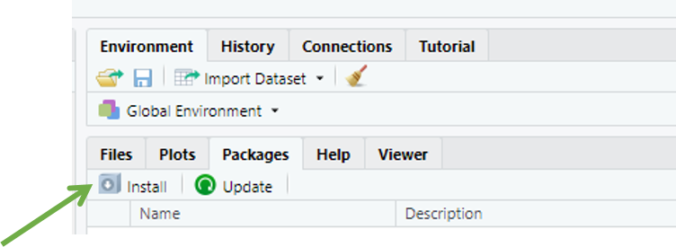

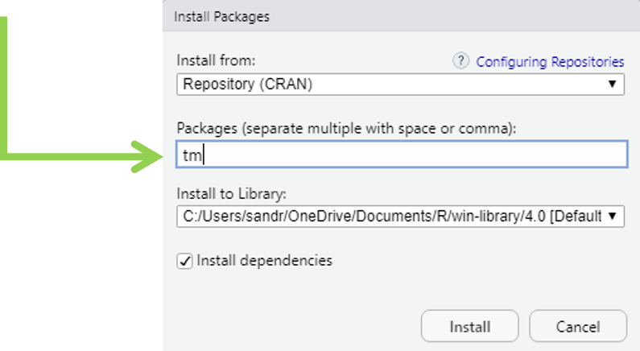

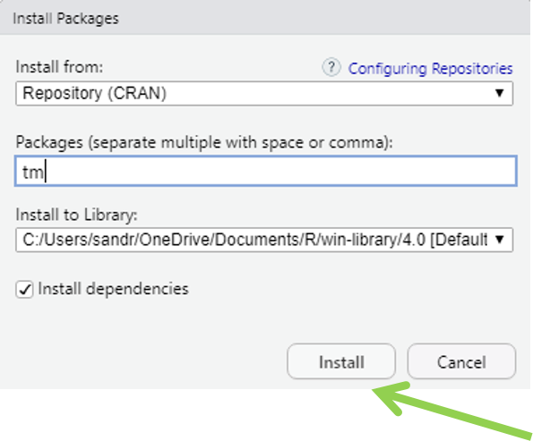

## Corpus Transformations

TM contains the following functions:

```r
getTransformations()
```

```
## [1] "removeNumbers"     "removePunctuation" "removeWords"
## [4] "stemDocument"      "stripWhitespace"
```

## Preparing data with the TM function

```r
words <- getwd()
words <- VCorpus(VectorSource(datos$Department.Description))
words [[1]][[1]]
```

```
## [1] "Research Division 2 Tempe"
```

```r
words [[2]][[1]]
```

```
## [1] "Sch Biological & Hlth Sys Engr"
```

```r
dataframe <- data.frame(text=unlist(sapply(words, `[`, "content")),
    stringsAsFactors=F)
```

This function removes any punctuation that we do not need for our data transformation

```r
words1 <- tm_map(words, removePunctuation)
words1 [[1]][[1]]
```

```
## [1] "Research Division 2 Tempe"
```

```r
words1 [[2]][[1]]
```

```
## [1] "Sch Biological  Hlth Sys Engr"
```

This function removes numbers from our data

```r
words2 <- tm_map(words1, removeNumbers)
words2 [[1]][[1]]
```

```
## [1] "Research Division  Tempe"
```

```r
words2 [[2]][[1]]
```

```
## [1] "Sch Biological  Hlth Sys Engr"
```

This function change our data to lower caps

```r
words3 <- tm_map(words2, content_transformer(tolower))
words3 [[1]][[1]]
```

```
## [1] "research division  tempe"
```

```r
words3 [[2]][[1]]
```

```
## [1] "sch biological  hlth sys engr"
```

This function returns various kinds of stopwords with support for different languages, in this case “English”

```r
words4 <- tm_map(words3, removeWords, stopwords ("english"))
words4 [[1]][[1]]
```

```
## [1] "research division  tempe"
```

```r
words4 [[2]][[1]]
```

```
## [1] "sch biological  hlth sys engr"
```

This function removes white spaces from our data

```r
words6 <- tm_map(words4, stripWhitespace)
words6 [[1]][[1]]
```

```
## [1] "research division tempe"
```

```r
words6 [[2]][[1]]
```

```
## [1] "sch biological hlth sys engr"
```

This function changes our data structure. Text mining packages work with a document-term matrix (or DTM)

```r
dtm <- DocumentTermMatrix(words6)
dtm [[1]][[1]]
```

```
## [1] 1
```

Now, our data is ready for our word cloud graphic.

# Word Cloud

## Wordcloud Package

The wordcloud package, created by Ian Fellows, creates pretty word clouds, visualize differences and similarity between documents, and avoid over-plotting in scatter plots with text.

## Installing the Package

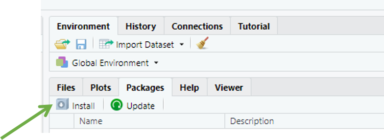

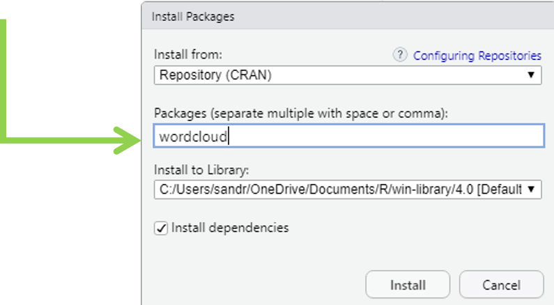

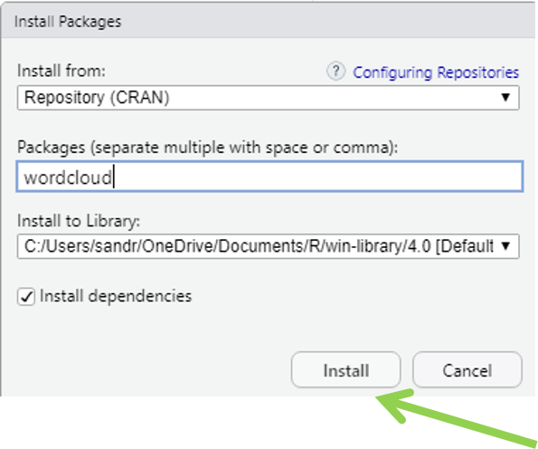

## Arguments

words - the words

freq - their frequencies

scale - A vector of length 2 indicating the range of the size of the words.

min.freq - words with frequency below min.freq will not be plotted

max.words - Maximum number of words to be plotted. least frequent terms dropped

random.order - plot words in random order. If false, they will be plotted in decreasing frequency

random.color - choose colors randomly from the colors. If false, the color is chosen based on the frequency

rot.per - proportion words with 90 degree rotation

colors - color words from least to most frequent

ordered.colors - if true, then colors are assigned to words in order

use.r.layout - if false, then c++ code is used for collision detection, otherwise R is used

fixed.asp - if TRUE, the aspect ratio is fixed. Variable aspect ratio only supported if rot.per==0

… - Additional parameters to be passed to text (and strheight,strwidth).

## Colors

The brewer function will help us to choose a palette to be used in out wordcloud

```r
color1 = brewer.pal(5, "BrBG")
color2 = brewer.pal(5, "Set2")
color3 = brewer.pal(5, "Paired")
display.brewer.all((colorblindFriendly=TRUE))
```

[output not shown]

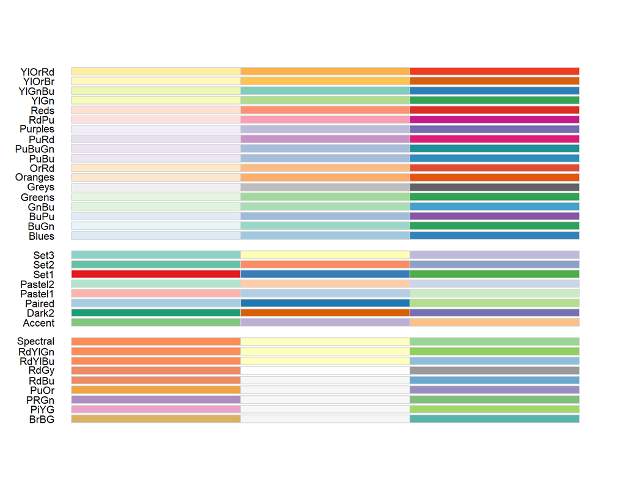

## Word Cloud Creation,

Figure 1 - All words horizontal

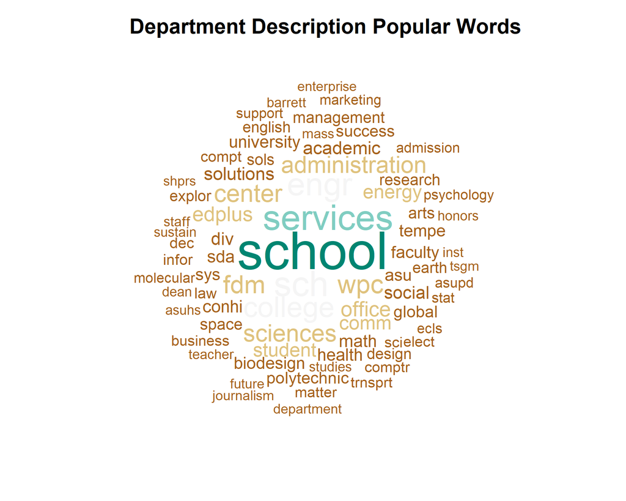

```r
wordcloud(words6,
          scale=c(5.0, 1),
          random.order = FALSE,
          max.words = 75,
          rot.per = 0,
          colors = color1)
title(main= "Department Description Popular Words",
      cex.main=2)
```

Figure 2 - Horizontal and Vertical words

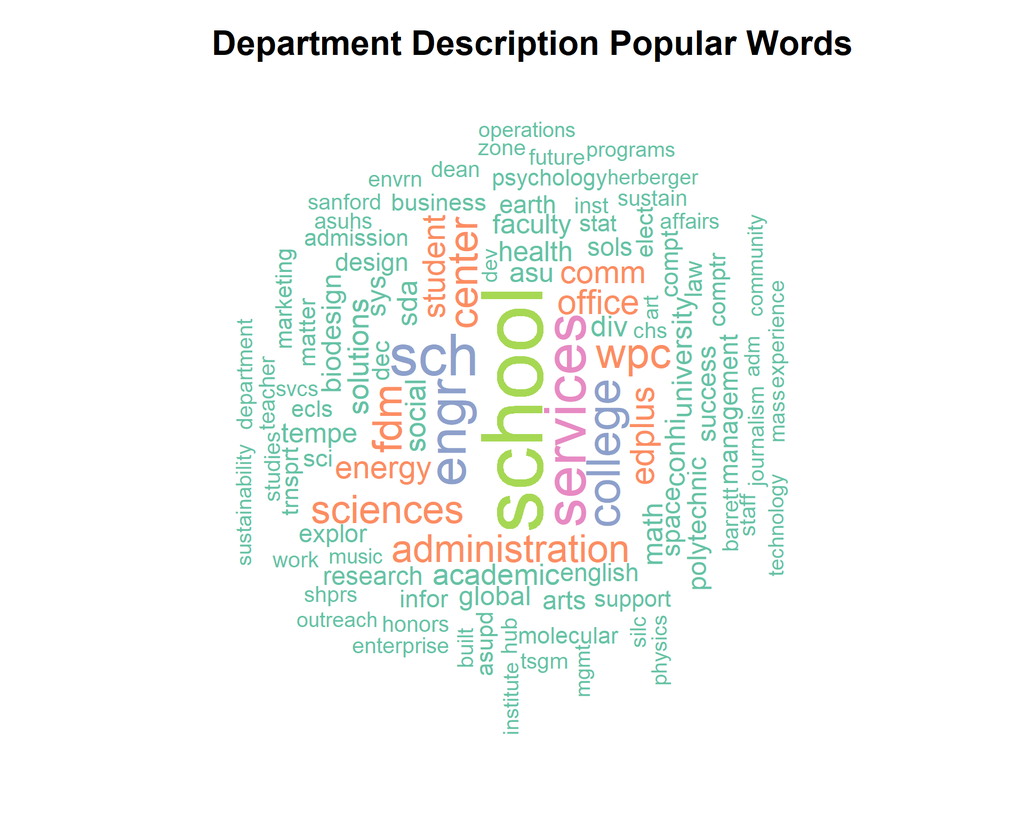

```r
wordcloud(words6,
          scale=c(5.0,1),
          random.order = FALSE,
          max.words = 100,
          rot.per = 0.50,
          colors = color2)
title(main= "Department Description Popular Words",
      cex.main=2)
```

Figure 3 - All Words Vertical

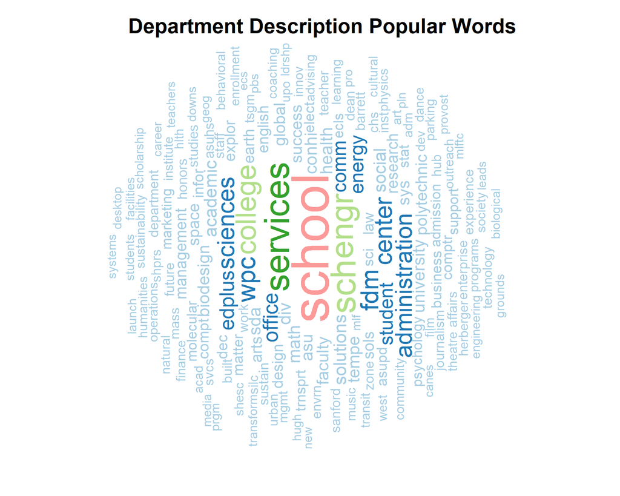

```r
wordcloud(words6,
          scale=c(5.0, 1),
          random.order = FALSE,
          max.words = 150,
          rot.per = 100,
          colors = color3)
title(main= "Department Description Popular Words",
      cex.main=2)
```

# Further Resources

Learn more about wordcloud() with the following link: [wordcloud: Plot a word cloud](https://www.rdocumentation.org/packages/wordcloud/versions/2.6/topics/wordcloud)

# Works Cited

This code through references and cites the following sources:

- tm package (ND). Source I. [Text Mining Package](https://cran.r-project.org/web/packages/tm/index.html)
- wordcloud package (ND). Source II. [Word Clouds](https://cran.r-project.org/web/packages/wordcloud/index.html)
- Wikipedia (ND). Source III. [Wikipedia](https://en.wikipedia.org/wiki/Text_mining)
- Wikipedia (ND). Source IV. [Wikipedia](https://en.wikipedia.org/wiki/Tag_cloud)
- Linkedin (2021). Source V. [Linkedin](https://www.linkedin.com/pulse/whats-60000-times-faster-than-reading-subject-line-alec-sharples/)